# Projet 2 : Analysez des données de systèmes éducatifs

Lecerf Defer Amandine

## Mise en place de l'environnement de travail

```python
import pandas as pd
import numpy as  np
import collections
import matplotlib.pyplot as plt
from matplotlib.pyplot import figure
import seaborn as sns
import inspect
import missingno as msno
import warnings
warnings.filterwarnings('ignore')

%matplotlib inline
```

```python
#Optimisation automatique des colonnes pour avoir un maximum d'information
pd.options.display.width = 0
```

## Découverte des données

### EdStatsCountry

```python
Stats_country = pd.read_csv("Data/EdStatsCountry.csv")
Stats_country.head()
```

|  | Country Code | Short Name | Table Name | Long Name | 2-alpha code | Currency Unit | Special Notes | Region | Income Group | WB-2 code | ... | IMF data dissemination standard | Latest population census | Latest household survey | Source of most recent Income and expenditure data | Vital registration complete | Latest agricultural census | Latest industrial data | Latest trade data | Latest water withdrawal data | Unnamed: 31 |
| --- | --- | --- | --- | --- | --- | --- | --- | --- | --- | --- | --- | --- | --- | --- | --- | --- | --- | --- | --- | --- | --- |
| 0 | ABW | Aruba | Aruba | Aruba | AW | Aruban florin | SNA data for 2000-2011 are updated from offici... | Latin America & Caribbean | High income: nonOECD | AW | ... | NaN | 2010 | NaN | NaN | Yes | NaN | NaN | 2012.0 | NaN | NaN |
| 1 | AFG | Afghanistan | Afghanistan | Islamic State of Afghanistan | AF | Afghan afghani | Fiscal year end: March 20; reporting period fo... | South Asia | Low income | AF | ... | General Data Dissemination System (GDDS) | 1979 | Multiple Indicator Cluster Survey (MICS), 2010/11 | Integrated household survey (IHS), 2008 | NaN | 2013/14 | NaN | 2012.0 | 2000 | NaN |
| 2 | AGO | Angola | Angola | People's Republic of Angola | AO | Angolan kwanza | April 2013 database update: Based on IMF data,... | Sub-Saharan Africa | Upper middle income | AO | ... | General Data Dissemination System (GDDS) | 1970 | Malaria Indicator Survey (MIS), 2011 | Integrated household survey (IHS), 2008 | NaN | 2015 | NaN | NaN | 2005 | NaN |
| 3 | ALB | Albania | Albania | Republic of Albania | AL | Albanian lek | NaN | Europe & Central Asia | Upper middle income | AL | ... | General Data Dissemination System (GDDS) | 2011 | Demographic and Health Survey (DHS), 2008/09 | Living Standards Measurement Study Survey (LSM... | Yes | 2012 | 2010.0 | 2012.0 | 2006 | NaN |
| 4 | AND | Andorra | Andorra | Principality of Andorra | AD | Euro | NaN | Europe & Central Asia | High income: nonOECD | AD | ... | NaN | 2011. Population figures compiled from adminis... | NaN | NaN | Yes | NaN | NaN | 2006.0 | NaN | NaN |

5 rows × 32 columns

Ce premier fichier nous donne des informations globales sur l'économie de chaque pays.

```python
Stats_country.shape
```

```
(241, 32)
```

Ce fichier possède 241 lignes et 32 colonnes (correspondants à des informations générales sur l'économie).

```python
Stats_country["Country Code"].nunique()
```

```
241
```

Chaque ligne correspond à un pays unique, il y a donc 241 pays analysés dans ce fichier.

```python
Stats_country.isna().sum().sort_values(ascending=False)
```

```
Unnamed: 31                                          241
National accounts reference year                     209
Alternative conversion factor                        194
Other groups                                         183
Latest industrial data                               134
Vital registration complete                          130
External debt Reporting status                       117
Latest household survey                              100
Latest agricultural census                            99
Lending category                                      97
PPP survey year                                       96
Special Notes                                         96
Source of most recent Income and expenditure data     81
Government Accounting concept                         80
Latest water withdrawal data                          62
Balance of Payments Manual in use                     60
IMF data dissemination standard                       60
Latest trade data                                     56
SNA price valuation                                   44
System of trade                                       41
National accounts base year                           36
Latest population census                              28
Income Group                                          27
Region                                                27
Currency Unit                                         26
System of National Accounts                           26
2-alpha code                                           3
WB-2 code                                              1
Long Name                                              0
Table Name                                             0
Short Name                                             0
Country Code                                           0
dtype: int64
```

Dans la plupart des colonnes il y a des données manquantes. La colonne Unnamed: 31 ne contient que des NaNs, elle n'est d'aucune utilité pour réaliser l'analyse, on peut donc la supprimer.

```python
Stats_country = Stats_country.drop(columns='Unnamed: 31')
```

```python
Stats_country.duplicated(keep=False).sum()
```

```
0
```

Le fichier ne contient pas de doublon.

### EdStatsCountry-Series

```python
Country_series = pd.read_csv("Data/EdStatsCountry-Series.csv")
Country_series.head()
```

|  | CountryCode | SeriesCode | DESCRIPTION | Unnamed: 3 |
| --- | --- | --- | --- | --- |
| 0 | ABW | SP.POP.TOTL | Data sources : United Nations World Population... | NaN |
| 1 | ABW | SP.POP.GROW | Data sources: United Nations World Population ... | NaN |
| 2 | AFG | SP.POP.GROW | Data sources: United Nations World Population ... | NaN |
| 3 | AFG | NY.GDP.PCAP.PP.CD | Estimates are based on regression. | NaN |
| 4 | AFG | SP.POP.TOTL | Data sources : United Nations World Population... | NaN |

Ce fichier contient les sources des données contenues dans le fichier précédent.

```python
Country_series.shape
```

```
(613, 4)
```

Ce fichier possède 613 lignes et 4 colonnes.

```python
Country_series["CountryCode"].nunique()
```

```
211
```

Il y a presque 3 fois plus de lignes que de country code (1 country code représente un pays unique), ce qui signifie qu'il y a plusieurs lignes par pays.

```python
Country_series.isna().sum().sort_values(ascending=False)
```

```
Unnamed: 3     613
DESCRIPTION      0
SeriesCode       0
CountryCode      0
dtype: int64
```

Il n'y a pas de donnée manquante sauf pour la colonne Unnamed: 3 qui ne contient que des NaNs, elle n'est d'aucune utilité pour réaliser l'analyse, on peut donc la supprimer.

```python
Country_series = Country_series.drop(columns='Unnamed: 3')
```

```python
Country_series.duplicated(keep=False).sum()
```

```
0
```

Le fichier ne contient pas de doublon.

### EdStatsData

```python
Stats_Data = pd.read_csv("Data/EdStatsData.csv")
Stats_Data.head()
```

|  | Country Name | Country Code | Indicator Name | Indicator Code | 1970 | 1971 | 1972 | 1973 | 1974 | 1975 | ... | 2060 | 2065 | 2070 | 2075 | 2080 | 2085 | 2090 | 2095 | 2100 | Unnamed: 69 |
| --- | --- | --- | --- | --- | --- | --- | --- | --- | --- | --- | --- | --- | --- | --- | --- | --- | --- | --- | --- | --- | --- |
| 0 | Arab World | ARB | Adjusted net enrolment rate, lower secondary, ... | UIS.NERA.2 | NaN | NaN | NaN | NaN | NaN | NaN | ... | NaN | NaN | NaN | NaN | NaN | NaN | NaN | NaN | NaN | NaN |
| 1 | Arab World | ARB | Adjusted net enrolment rate, lower secondary, ... | UIS.NERA.2.F | NaN | NaN | NaN | NaN | NaN | NaN | ... | NaN | NaN | NaN | NaN | NaN | NaN | NaN | NaN | NaN | NaN |
| 2 | Arab World | ARB | Adjusted net enrolment rate, lower secondary, ... | UIS.NERA.2.GPI | NaN | NaN | NaN | NaN | NaN | NaN | ... | NaN | NaN | NaN | NaN | NaN | NaN | NaN | NaN | NaN | NaN |
| 3 | Arab World | ARB | Adjusted net enrolment rate, lower secondary, ... | UIS.NERA.2.M | NaN | NaN | NaN | NaN | NaN | NaN | ... | NaN | NaN | NaN | NaN | NaN | NaN | NaN | NaN | NaN | NaN |
| 4 | Arab World | ARB | Adjusted net enrolment rate, primary, both sex... | SE.PRM.TENR | 54.822121 | 54.894138 | 56.209438 | 57.267109 | 57.991138 | 59.36554 | ... | NaN | NaN | NaN | NaN | NaN | NaN | NaN | NaN | NaN | NaN |

5 rows × 70 columns

```python
Stats_Data.shape
```

```
(886930, 70)
```

Ce fichier possède 886930 lignes et 70 colonnes.

```python
Stats_Data["Country Code"].nunique()
```

```
242
```

Il y a beaucoup plus de lignes que de nombre de pays (environ 3665 lignes par pays). Au vu de la nature du fichier, on peut supposer qu'il y a 3665 indicateurs renseignés pour chaque pays.

```python
Stats_Data.isna().sum().sort_values(ascending=False)
```

```
Unnamed: 69       886930
2017              886787
2016              870470
1971              851393
1973              851385
                   ...
2010              644488
Indicator Code         0
Indicator Name         0
Country Code           0
Country Name           0
Length: 70, dtype: int64
```

```python
Stats_Data = Stats_Data.drop(columns='Unnamed: 69')
```

```python
Stats_Data.duplicated(keep=False).sum()
```

```
0
```

Le fichier ne contient pas de doublon.

### EdStatsFootNote

```python
FootNote = pd.read_csv("Data/EdStatsFootNote.csv")
FootNote.head()
```

|  | CountryCode | SeriesCode | Year | DESCRIPTION | Unnamed: 4 |
| --- | --- | --- | --- | --- | --- |
| 0 | ABW | SE.PRE.ENRL.FE | YR2001 | Country estimation. | NaN |
| 1 | ABW | SE.TER.TCHR.FE | YR2005 | Country estimation. | NaN |
| 2 | ABW | SE.PRE.TCHR.FE | YR2000 | Country estimation. | NaN |
| 3 | ABW | SE.SEC.ENRL.GC | YR2004 | Country estimation. | NaN |
| 4 | ABW | SE.PRE.TCHR | YR2006 | Country estimation. | NaN |

Ce fichier donne des informations sur l'année d'origine des données correspondant à chaque indicateur pour chaque pays.

```python
FootNote.shape
```

```
(643638, 5)
```

Ce fichier possède 643638 lignes et 5 colonnes.

```python
FootNote["CountryCode"].nunique()
```

```
239
```

Dans ce dataset, 239 pays sont représentés.

```python
FootNote.isna().sum().sort_values(ascending=False)
```

```
Unnamed: 4     643638
DESCRIPTION         0
Year                0
SeriesCode          0
CountryCode         0
dtype: int64
```

Il n'y a pas de donnée manquante. Seule la colonne Unnamed: 4 ne contient que des NaNs, elle n'est d'aucune utilité pour réaliser l'analyse, on peut donc la supprimer.

```python
FootNote = FootNote.drop(columns='Unnamed: 4')
```

```python
FootNote.duplicated(keep=False).sum()
```

```
0
```

Le fichier ne contient pas de doublon.

### EdStatsSeries

```python
StatsSeries = pd.read_csv("Data/EdStatsSeries.csv")
StatsSeries.head()
```

|  | Series Code | Topic | Indicator Name | Short definition | Long definition | Unit of measure | Periodicity | Base Period | Other notes | Aggregation method | ... | Notes from original source | General comments | Source | Statistical concept and methodology | Development relevance | Related source links | Other web links | Related indicators | License Type | Unnamed: 20 |
| --- | --- | --- | --- | --- | --- | --- | --- | --- | --- | --- | --- | --- | --- | --- | --- | --- | --- | --- | --- | --- | --- |
| 0 | BAR.NOED.1519.FE.ZS | Attainment | Barro-Lee: Percentage of female population age... | Percentage of female population age 15-19 with... | Percentage of female population age 15-19 with... | NaN | NaN | NaN | NaN | NaN | ... | NaN | NaN | Robert J. Barro and Jong-Wha Lee: http://www.b... | NaN | NaN | NaN | NaN | NaN | NaN | NaN |
| 1 | BAR.NOED.1519.ZS | Attainment | Barro-Lee: Percentage of population age 15-19 ... | Percentage of population age 15-19 with no edu... | Percentage of population age 15-19 with no edu... | NaN | NaN | NaN | NaN | NaN | ... | NaN | NaN | Robert J. Barro and Jong-Wha Lee: http://www.b... | NaN | NaN | NaN | NaN | NaN | NaN | NaN |
| 2 | BAR.NOED.15UP.FE.ZS | Attainment | Barro-Lee: Percentage of female population age... | Percentage of female population age 15+ with n... | Percentage of female population age 15+ with n... | NaN | NaN | NaN | NaN | NaN | ... | NaN | NaN | Robert J. Barro and Jong-Wha Lee: http://www.b... | NaN | NaN | NaN | NaN | NaN | NaN | NaN |
| 3 | BAR.NOED.15UP.ZS | Attainment | Barro-Lee: Percentage of population age 15+ wi... | Percentage of population age 15+ with no educa... | Percentage of population age 15+ with no educa... | NaN | NaN | NaN | NaN | NaN | ... | NaN | NaN | Robert J. Barro and Jong-Wha Lee: http://www.b... | NaN | NaN | NaN | NaN | NaN | NaN | NaN |
| 4 | BAR.NOED.2024.FE.ZS | Attainment | Barro-Lee: Percentage of female population age... | Percentage of female population age 20-24 with... | Percentage of female population age 20-24 with... | NaN | NaN | NaN | NaN | NaN | ... | NaN | NaN | Robert J. Barro and Jong-Wha Lee: http://www.b... | NaN | NaN | NaN | NaN | NaN | NaN | NaN |

5 rows × 21 columns

Ce fichier donne des informations sur les indicateurs socio-économiques étudiés pour chaque pays.

```python
StatsSeries.shape
```

```
(3665, 21)
```

Ce fichier possède 3665 lignes et 21 colonnes.

```python
StatsSeries["Indicator Name"].nunique()
```

```
3665
```

Dans ce dataset, il y a des informations pour les 3665 indicateurs étudiés dans chaque pays

```python
StatsSeries.isna().sum().sort_values(ascending=False)
```

```
Unnamed: 20                            3665
Related indicators                     3665
Other web links                        3665
Unit of measure                        3665
License Type                           3665
Notes from original source             3665
Development relevance                  3662
General comments                       3651
Limitations and exceptions             3651
Statistical concept and methodology    3642
Aggregation method                     3618
Periodicity                            3566
Related source links                   3450
Base Period                            3351
Other notes                            3113
Short definition                       1509
Source                                    0
Long definition                           0
Indicator Name                            0
Topic                                     0
Series Code                               0
dtype: int64
```

Il y a de nombreuses données manquantes. Plusieurs colonnes (Unnamed: 20, Related indicators, Other web links, Unit of measure, License Type, Notes from original source) ne contiennent que des NaNs. La colonne Unname: 20 n'est d'aucune utilité pour réaliser l'analyse, on peut donc la supprimer.

```python
StatsSeries = StatsSeries.drop(columns='Unnamed: 20')
```

```python
StatsSeries.duplicated(keep=False).sum()
```

```
0
```

Le fichier ne contient pas de doublon.

### Bilan sur les Datasets

```python
def retrieve_name(var):
    '''afficher le nom d\'une variable '''
    callers_local_vars = inspect.currentframe().f_back.f_locals.items()
    return [var_name for var_name, var_val in callers_local_vars if var_val is var]
list_dataset = [Stats_country, Country_series, Stats_Data, FootNote, StatsSeries]
for dataset in list_dataset:
    print('Le Dataset {} possède {} lignes et {} colonnes.'.format(retrieve_name(dataset)[0], dataset.shape[0], dataset.shape[1]))
```

```
Le Dataset Stats_country possède 241 lignes et 31 colonnes.
Le Dataset Country_series possède 613 lignes et 3 colonnes.
Le Dataset Stats_Data possède 886930 lignes et 69 colonnes.
Le Dataset FootNote possède 643638 lignes et 4 colonnes.
Le Dataset StatsSeries possède 3665 lignes et 20 colonnes.
```

### Bilan sur les données disponibles

- Le dataset comporte bien des données éducatives
- Tous les pays du monde semblent y être intégrés
- Il semble y avoir un nombre important de données par pays pour procéder à des analyses comparatives

## Pré Analyse des données

### **Choix de la période d'étude**

```python
#Formatage des noms de Year pour supprimer le YR et n'avoir que l'année, exemple : YR2010 devient 2010
FootNote['Year'] = FootNote['Year'].apply(lambda x : x[2:])
```

```python
FootNote['Year'].sort_values().unique()
```

```
array(['1970', '1971', '1972', '1973', '1974', '1975', '1976', '1977',
       '1978', '1979', '1980', '1981', '1982', '1983', '1984', '1985',
       '1986', '1987', '1988', '1989', '1990', '1991', '1992', '1993',
       '1994', '1995', '1996', '1997', '1998', '1999', '2000', '2001',
       '2002', '2003', '2004', '2005', '2006', '2007', '2008', '2009',
       '2010', '2011', '2012', '2013', '2014', '2015', '2016', '2017',
       '2020', '2025', '2030', '2035', '2040', '2045', '2050'],
      dtype=object)
```

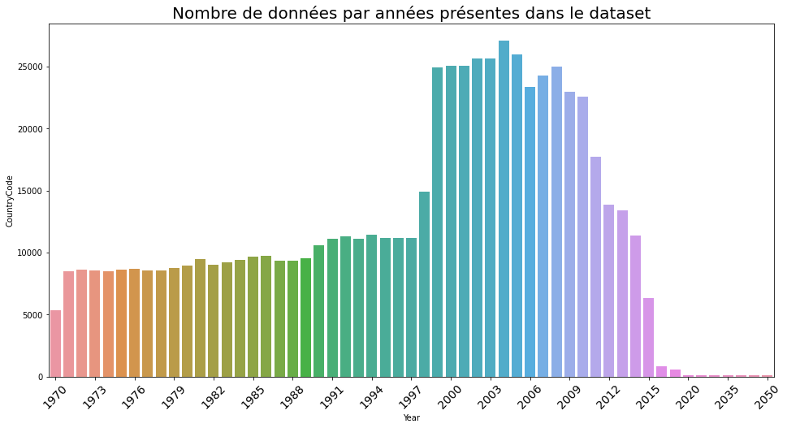

```python
plt.figure(figsize=(16, 8))
data = FootNote.groupby('Year').count().reset_index()
#data["Year"]=int(data["Year"])
sns.barplot(y = data["CountryCode"], x=data["Year"])
plt.xticks(rotation=45, size=14)
plt.title("Nombre de données par années présentes dans le dataset", size=20)
plt.gca().xaxis.set_major_locator(plt.MultipleLocator(3))
plt.show()
```

On retrouve **la majorité des données entre 1998 et 2013**. Ce sont donc les données correspondantes à cette période qui sont utilisées pour l'analyse.

### **Choix des pays pour l'étude**

#### Liste des régions

```python
region = Stats_country["Region"].unique()
region
```

```
array(['Latin America & Caribbean', 'South Asia', 'Sub-Saharan Africa',
       'Europe & Central Asia', nan, 'Middle East & North Africa',
       'East Asia & Pacific', 'North America'], dtype=object)
```

On remarque que les pays sont répartis dans différentes régions du monde que l'on retrouve dans la colonne Region du fichier Stats_country. Cependant, on voit qu'il y a 7 régions bien définies et des NaNs. Il faut donc rechercher dans la colonne Long Name à quoi correspond les NaNs. Hypothèse : Des régions ont été mal répertoriées.

Recherche des lignes contenant NaNs comme valeur pour région et céation d'un DataFrame intermédiaire

```python
Liste_indexNAN = Stats_country.loc[pd.isna(Stats_country["Region"]), :].index
Liste_indexNAN
```

```
Int64Index([  5,  57,  58,  59,  60,  63,  68,  78,  89,  92, 116, 122, 123,
            124, 127, 128, 140, 143, 148, 157, 166, 168, 187, 198, 200, 225,
            234],
           dtype='int64')
```

```python
Find_Region = pd.DataFrame(columns=["Country Code","Short Name","Table Name","Long Name","2-alpha code","Currency Unit","Special Notes","Region","Income Group","WB-2 code","National accounts base year","National accounts reference year","SNA price valuation","Lending category","Other groups","System of National Accounts","Alternative conversion factor","PPP survey year","Balance of Payments Manual in use","External debt Reporting status","System of trade","Government Accounting concept","IMF data dissemination standard","Latest population census","Latest household survey","Source of most recent Income and expenditure data","Vital registration complete","Latest agricultural census","Latest industrial data","Latest trade data","Latest water withdrawal data",])
```

```python
a = Find_Region.append(Stats_country.iloc[5])
b = a.append(Stats_country.iloc[57])
c = b.append(Stats_country.iloc[58])
a = c.append(Stats_country.iloc[59])
b = a.append(Stats_country.iloc[60])
c = b.append(Stats_country.iloc[63])
a = c.append(Stats_country.iloc[68])
b = a.append(Stats_country.iloc[78])
c = b.append(Stats_country.iloc[89])
a = c.append(Stats_country.iloc[92])
b = a.append(Stats_country.iloc[116])
c = b.append(Stats_country.iloc[122])
a = c.append(Stats_country.iloc[123])
b = a.append(Stats_country.iloc[124])
c = b.append(Stats_country.iloc[127])
a = c.append(Stats_country.iloc[128])
b = a.append(Stats_country.iloc[140])
c = b.append(Stats_country.iloc[143])
a = c.append(Stats_country.iloc[148])
b = a.append(Stats_country.iloc[157])
c = b.append(Stats_country.iloc[166])
a = c.append(Stats_country.iloc[168])
b = a.append(Stats_country.iloc[187])
c = b.append(Stats_country.iloc[198])
a = c.append(Stats_country.iloc[200])
b = a.append(Stats_country.iloc[225])
Find_Region = b.append(Stats_country.iloc[234])
Find_Region.head()
```

|  | Country Code | Short Name | Table Name | Long Name | 2-alpha code | Currency Unit | Special Notes | Region | Income Group | WB-2 code | ... | Government Accounting concept | IMF data dissemination standard | Latest population census | Latest household survey | Source of most recent Income and expenditure data | Vital registration complete | Latest agricultural census | Latest industrial data | Latest trade data | Latest water withdrawal data |
| --- | --- | --- | --- | --- | --- | --- | --- | --- | --- | --- | --- | --- | --- | --- | --- | --- | --- | --- | --- | --- | --- |
| 5 | ARB | Arab World | Arab World | Arab World | 1A | NaN | Arab World aggregate. Arab World is composed o... | NaN | NaN | 1A | ... | NaN | NaN | NaN | NaN | NaN | NaN | NaN | NaN | NaN | NaN |
| 57 | EAP | East Asia & Pacific (developing only) | East Asia & Pacific | East Asia & Pacific (developing only) | 4E | NaN | East Asia and Pacific regional aggregate (does... | NaN | NaN | 4E | ... | NaN | NaN | NaN | NaN | NaN | NaN | NaN | NaN | NaN | NaN |
| 58 | EAS | East Asia & Pacific (all income levels) | East Asia & Pacific (all income levels) | East Asia & Pacific (all income levels) | Z4 | NaN | East Asia and Pacific regional aggregate (incl... | NaN | NaN | Z4 | ... | NaN | NaN | NaN | NaN | NaN | NaN | NaN | NaN | NaN | NaN |
| 59 | ECA | Europe & Central Asia (developing only) | Europe & Central Asia | Europe & Central Asia (developing only) | 7E | NaN | Europe and Central Asia regional aggregate (do... | NaN | NaN | 7E | ... | NaN | NaN | NaN | NaN | NaN | NaN | NaN | NaN | NaN | NaN |
| 60 | ECS | Europe & Central Asia (all income levels) | Europe & Central Asia (all income levels) | Europe & Central Asia (all income levels) | Z7 | NaN | Europe and Central Asia regional aggregate (in... | NaN | NaN | Z7 | ... | NaN | NaN | NaN | NaN | NaN | NaN | NaN | NaN | NaN | NaN |

5 rows × 31 columns

```python
find_region = Find_Region["Short Name"].unique()
find_region
```

```
array(['Arab World', 'East Asia & Pacific (developing only)',
       'East Asia & Pacific (all income levels)',
       'Europe & Central Asia (developing only)',
       'Europe & Central Asia (all income levels)', 'Euro area',
       'European Union', 'Gibraltar', 'High income',
       'Heavily indebted poor countries (HIPC)',
       'Latin America & Caribbean (developing only)',
       'Latin America & Caribbean (all income levels)',
       'Least developed countries: UN classification', 'Low income',
       'Lower middle income', 'Low & middle income',
       'Middle East & North Africa (all income levels)', 'Middle income',
       'Middle East & North Africa (developing only)', 'North America',
       'Nauru', 'OECD members', 'South Asia',
       'Sub-Saharan Africa (developing only)',
       'Sub-Saharan Africa (all income levels)', 'Upper middle income',
       'World'], dtype=object)
```

On voit qu'il y a, dans region et find region, un certain nombre de noms qui correspondent en fait à des zones. Une liste areas est créée et contient les différentes régions du monde représentées.

```python
areas = ['Arab World',
         'East Asia & Pacific',
         'Europe & Central Asia',
         'Latin America & Caribbean',
         'Middle East & North Africa',
         'North America',
         'South Asia',
         'Sub-Saharan Africa'
        ]
```

```python
len(areas)
```

```
8
```

On peut enlever certaines régions car elles ne permettent pas de donner des informations précises : Euro area','European Union', 'OECD members','Heavily indebted poor countries (HIPC)', 'High income', 'Least developed countries: UN classification', 'Low & middle income','Low income','Lower middle income', 'Middle income','Upper middle income', 'World'.

#### Répartition des pays selon leur région, leur devise et leur Revenu

###### Répartition des pays selon leur région

Comment sont répartis les pays étudiés dans les différentes zones du monde. Quelles sont les zones les plus représentées ?

```python
y = Stats_country.groupby('Region')[['Short Name']].count()['Short Name'].sort_values(ascending=False)
y
```

```
Region
Europe & Central Asia         57
Sub-Saharan Africa            48
Latin America & Caribbean     41
East Asia & Pacific           36
Middle East & North Africa    21
South Asia                     8
North America                  3
Name: Short Name, dtype: int64
```

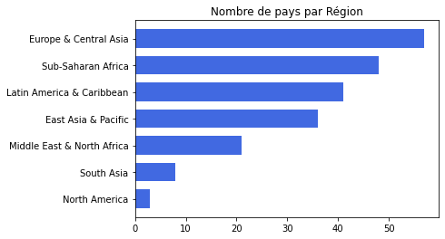

```python
plt.figure
plt.barh(y = Stats_country.groupby('Region')[['Short Name']].count().reset_index().sort_values(by='Short Name')['Region'], width = Stats_country.groupby("Region")[["Short Name"]].count()["Short Name"].sort_values(), height=0.7, align='center', color = "royalblue",linewidth = 0.8)
ax = plt.gca()
plt.title('Nombre de pays par Région')
plt.show()
```

Dans cette étude, Europe & Central Asia, Sub-Saharan Africa, Latin America & Caribbea, East Asia & Pacific sont les régions les plus représentées.

##### Répartition des pays selon leur devise

Quelle sont les devises les plus représentées ?

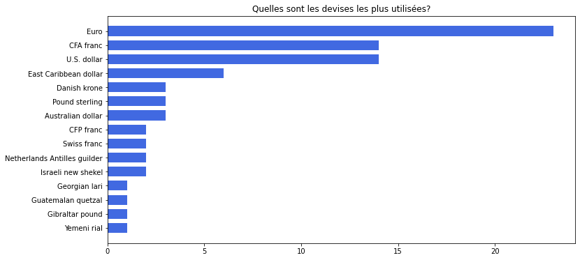

```python
plt.figure(figsize=(12,6))
plt.barh(y = Stats_country.groupby('Currency Unit')[['Short Name']].count().reset_index().sort_values(by='Short Name')['Currency Unit'].tail(15), width = Stats_country.groupby('Currency Unit')[['Short Name']].count()['Short Name'].sort_values().tail(15), height=0.7, align='center', color = "royalblue")
plt.title('Quelles sont les devises les plus utilisées?')
plt.show()
```

L'Euro est fortement majoritaire au sein des pays étudiés.

##### Répartition des pays selon leur Revenu

Quels sont les niveaux économiques les plus représentés dans cette étude ?

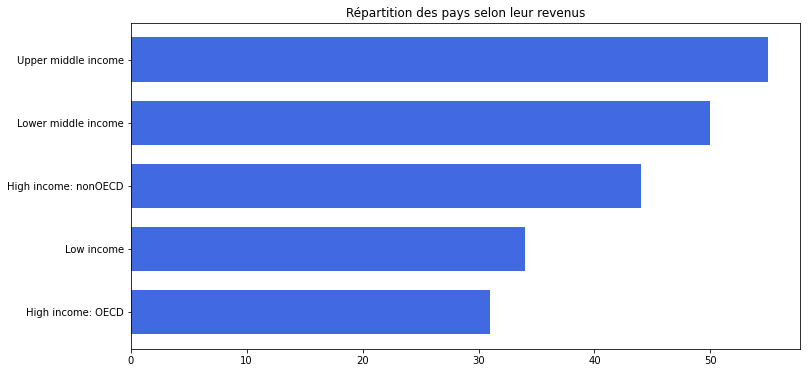

```python
plt.figure(figsize=(12,6))
plt.barh(y = Stats_country.groupby('Income Group')[['Short Name']].count().reset_index().sort_values(by='Short Name')['Income Group'], width = Stats_country.groupby("Income Group")[["Short Name"]].count()["Short Name"].sort_values(), height=0.7, align='center', color = "royalblue",linewidth = 1)
ax = plt.gca()
plt.title('Répartition des pays selon leur revenus')
plt.show()

# , edgecolor = "green"
```

Les pays les plus représentés dans l'étude ont des revenus corrects (moyen).

#### Filtration des pays

###### Liste des pays

Quels sont les pays qui se trouvent dans les zones géographiques précédement étudiées ?

```python
Stats_country[~Stats_country['Short Name'].isin(areas)]['Short Name'].unique().shape
```

```
(238,)
```

```python
List_countries = Stats_country[~Stats_country['Short Name'].isin(areas)]['Short Name'].unique().tolist()
#list(List_countries)
```

###### Filtration du nombre de pays

Quels sont les pays que l'on peut supprimer de l'étude pour affiner nos recherches ?

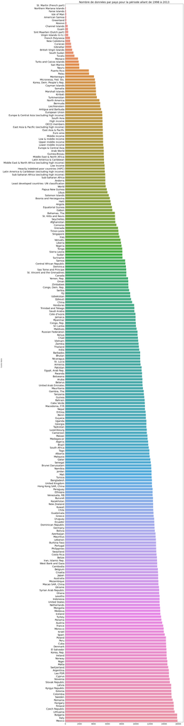

```python
plt.figure(figsize=(16, 100))
plt.title("Nombre de données par pays pour la période allant de 1998 à 2013", size=20)
data = Stats_Data
sns.barplot(x = data.groupby('Country Name')[['1998', '1999', '2000', '2001', '2002', '2003', '2004', '2005',
       '2006', '2007', '2008', '2009', '2010', '2011', '2012', '2013']].count().sum(axis=1).sort_values(ascending=True).values,
                   y = data.groupby('Country Name')[['1998', '1999', '2000', '2001', '2002', '2003', '2004', '2005',
       '2006', '2007', '2008', '2009', '2010', '2011', '2012', '2013']].count().sum(axis=1).sort_values(ascending=True).index)
plt.yticks(fontsize=18)
plt.xticks(fontsize=14)
plt.show()
```

```python
to_remove = (data.groupby('Country Name')[['1998', '1999', '2000', '2001', '2002', '2003', '2004', '2005',
       '2006', '2007', '2008', '2009', '2010', '2011', '2012', '2013']].count().sum(axis=1).sort_values(ascending=True).values)<6000
to_remove = to_remove.tolist()
to_remove.count(True)
```

```
64
```

Les 64 premiers pays (lorsque le classement des pays selon le nombre de données est croissant) sont ceux qui ont moins de 6000 données sur la période d'étude de 1998 à 2013.

```python
pays_total = data.groupby('Country Name')[['1998', '1999', '2000', '2001', '2002', '2003', '2004', '2005',
       '2006', '2007', '2008', '2009', '2010', '2011', '2012', '2013']].count().sum(axis=1).sort_values(ascending=True).index.tolist()
remove = pays_total[:64]
#remove
```

Les pays pour lesquels on a le moins d'informations (moins de 6000 données pour la période d'étude choisie) sont :

- Les petits pays
- Les nouveaux pays (kosovo)
- Les régions de certains pays : st martin, french polynésia, ...

Je décide de supprimer certains pays où il serait difficile de développer notre activité au vu de la situation du pays (démographie, économique, éducatif, ...).

Je décide aussi de supprimer les régions de certains pays (st martin, french polynésia, ...).

Je décide aussi de supprimer des catégories qui ne sont pas des pays et qui ne nous donne pas d'information précise (World, Least developed countries: UN classification, Low income, Lower middle income, Low & middle income).

```python
countries = ['Albania', 'United Arab Emirates', 'Argentina', 'Armenia', 'Australia', 'Austria', 'Azerbaijan', 'Burundi', 'Belgium', 'Bulgaria', 'Bahrain', 'The Bahamas', 'Bosnia and Herzegovina', 'Belarus', 'Belize', 'Bolivia', 'Brazil', 'Barbados', 'Bhutan', 'Canada', 'Switzerland', 'Chile', 'China', "Côte d'Ivoire", 'Colombia', 'Costa Rica', 'Cuba', 'Cyprus', 'Czech Republic', 'Germany', 'Denmark', 'Dominican Republic', 'Algeria', 'Ecuador', 'Egypt', 'Eritrea', 'Spain', 'Estonia', 'Finland', 'France', 'United Kingdom', 'Georgia', 'Guinea', 'Greece', 'Grenada', 'Guatemala', 'Guyana', 'Hong Kong SAR, China', 'Honduras', 'Croatia', 'Hungary', 'Indonesia', 'India', 'Ireland', 'Iran', 'Iraq', 'Iceland', 'Israel', 'Italy', 'Jamaica', 'Jordan', 'Japan', 'Kenya', 'Cambodia', 'Korea', 'Kuwait', 'Lao PDR', 'Lebanon', 'Sri Lanka', 'Lesotho', 'Lithuania', 'Luxembourg', 'Latvia', 'Morocco', 'Moldova', 'Madagascar', 'Mexico', 'Macedonia', 'Malta', 'Myanmar', 'Mongolia', 'Mauritius', 'Malaysia', 'Niger', 'Nigeria', 'Nicaragua', 'Netherlands', 'Norway', 'New Zealand', 'Oman', 'Pakistan', 'Panama', 'Peru', 'Philippines', 'Poland', "Dem. People's Rep. Korea", 'Portugal', 'Paraguay', 'Qatar', 'Romania', 'Russia', 'Saudi Arabia', 'Sudan', 'Senegal', 'Singapore', 'Serbia', 'Suriname', 'Slovak Republic', 'Slovenia', 'Sweden', 'Chad', 'Togo', 'Thailand', 'Tunisia', 'Turkey', 'Tanzania', 'Uganda', 'Ukraine','Uruguay', 'United States', 'Venezuela', 'Vietnam', 'Yemen', 'South Africa']
#list(countries)
```

```python
len(countries)
```

```
124
```

```python
Data_Study = Stats_Data.merge(right = Stats_country[['Country Code', 'Region']],
                  on='Country Code', how='left')
```

```python
Data_Study["Study_years"] = Stats_Data[[str(year) for year in [1999,2010]]].mean(1)
Data_Study = Data_Study[["Country Name", "Country Code", "Indicator Name", "Indicator Code", "Region", "Study_years"]]
Data_Study
```

|  | Country Name | Country Code | Indicator Name | Indicator Code | Region | Study_years |
| --- | --- | --- | --- | --- | --- | --- |
| 0 | Arab World | ARB | Adjusted net enrolment rate, lower secondary, ... | UIS.NERA.2 | NaN | NaN |
| 1 | Arab World | ARB | Adjusted net enrolment rate, lower secondary, ... | UIS.NERA.2.F | NaN | NaN |
| 2 | Arab World | ARB | Adjusted net enrolment rate, lower secondary, ... | UIS.NERA.2.GPI | NaN | NaN |
| 3 | Arab World | ARB | Adjusted net enrolment rate, lower secondary, ... | UIS.NERA.2.M | NaN | NaN |
| 4 | Arab World | ARB | Adjusted net enrolment rate, primary, both sex... | SE.PRM.TENR | NaN | 80.733158 |
| ... | ... | ... | ... | ... | ... | ... |
| 886925 | Zimbabwe | ZWE | Youth illiterate population, 15-24 years, male... | UIS.LP.AG15T24.M | Sub-Saharan Africa | NaN |
| 886926 | Zimbabwe | ZWE | Youth literacy rate, population 15-24 years, b... | SE.ADT.1524.LT.ZS | Sub-Saharan Africa | NaN |
| 886927 | Zimbabwe | ZWE | Youth literacy rate, population 15-24 years, f... | SE.ADT.1524.LT.FE.ZS | Sub-Saharan Africa | NaN |
| 886928 | Zimbabwe | ZWE | Youth literacy rate, population 15-24 years, g... | SE.ADT.1524.LT.FM.ZS | Sub-Saharan Africa | NaN |
| 886929 | Zimbabwe | ZWE | Youth literacy rate, population 15-24 years, m... | SE.ADT.1524.LT.MA.ZS | Sub-Saharan Africa | NaN |

886930 rows × 6 columns

### **Choix des indicateurs pour l'étude**

#### Liste des indicateurs

```python
List_indicator = Stats_Data["Indicator Name"].unique()
#list(List_indicator)
```

```python
Stats_Data["Indicator Name"].nunique()
```

```
3665
```

Pour notre étude nous avons à notre disposition 3665 indicateurs.

```python
x=Stats_Data.groupby('Country Name')[['Indicator Code']].count().reset_index()
dico = x.set_index('Country Name').T.to_dict('list')
```

```python
for k,v in dico.items():
    if v != [3665]:
        print("Le {0} ne traite pas la totalité des indicateurs, il en traite {1}".format(k,v))
print("Si vous ne voyez pas de sortie, celà signifie que tous les pays étudiés traitent les 3665 indicateurs")
```

```
Si vous ne voyez pas de sortie, celà signifie que tous les pays étudiés traitent les 3665 indicateurs
```

**Tout les pays sélectionnés précédement traitent les 3665 indicateurs (mais il peut y avoir des données manquantes).**

#### Quels sont les indicateurs les plus utilisés ?

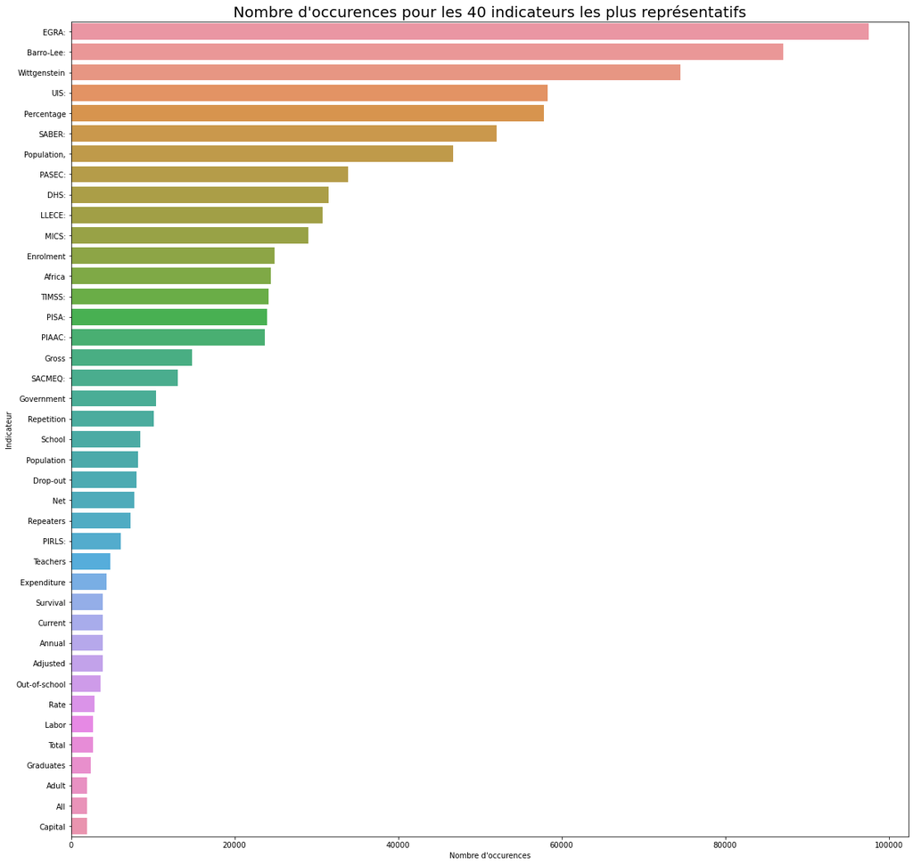

```python
liste_indicateurs = [i.split(' ', 1)[0] for i in Stats_Data['Indicator Name'].tolist()]
indicateurs_populaires = collections.Counter(liste_indicateurs).most_common(40)
DataFrame_indicateurs_populaires = pd.DataFrame(indicateurs_populaires, columns = ['Indicateur', 'Nombre Occurences']).sort_values(by='Nombre Occurences', ascending=False)

plt.figure(figsize=(20, 20))
sns.barplot(y = DataFrame_indicateurs_populaires["Indicateur"], x=DataFrame_indicateurs_populaires["Nombre Occurences"])
plt.title("Nombre d\'occurences pour les 40 indicateurs les plus représentatifs", size=20)
plt.xlabel('Nombre d\'occurences')
plt.show()
```

Les indicateurs que l'on retrouve le plus avec un grand nombre d'occurences sont en relation avec l'éducation.

**Parmis les 40 occurences les plus représentées dans ce jeu de données, 10 indicateurs sont en rapport avec l'éducation :**

- EGRA : Early Grade Reading Assessment (évaluations internationales de l'apprentissage, lecture );
- Barro-lee : Dataset relatif à l'éducation
- Wittgenstein (Wittgenstein Centre Human Capital Data Explore)
- UIS : UNESCO Institut de Statistiques
- PISA : Tests comparatifs de compétences pour les élèves
- school
- Teachers;
- out of school
- graduate.
- Net : L'accès à internet

#### Quels sont les indicateurs avec le plus de données ?

```python
Data_Study[["Indicator Name", "Study_years"]].groupby("Indicator Name").count().sort_values(by="Study_years", ascending=False)
```

| Indicator Name | Study_years |
| --- | --- |
| Population, total | 240 |
| Population growth (annual %) | 240 |
| GDP per capita (current US$) | 232 |
| GDP at market prices (current US$) | 232 |
| Internet users (per 100 people) | 229 |
| ... | ... |
| EGRA: Oral Reading Fluency - Share of students with a zero score (%). Songhoi. 2nd Grade | 0 |
| EGRA: Oral Reading Fluency - Share of students with a zero score (%). Spanish. 2nd Grade | 0 |
| EGRA: Correct Non-Words Read Per Minute (Mean). Nzema. 2nd Grade | 0 |
| EGRA: Correct Non-Words Read Per Minute (Mean). Luvale. 2nd Grade | 0 |
| PASEC: Mean performance on the mathematics scale for 6th grade students. Male | 0 |

3665 rows × 1 columns

Indicateurs dont nous avons besoin pour répondre à notre étude :

- indicateur pour quantifier l'utilisation d'internet par pays
- indicateur pour quantifier le nombre d'etudiants / lycéens

#### Indicateurs choisis

En observant les indicateurs avec le plus de données, on peut déterminer 4 indicateurs pour la suite de l'étude.

## indicateur précis

### education

- **SE.SEC.ENRL** = Enrolment in secondary education, both sexes (number)
- **SE.TER.ENRL** = Enrolment in tertiary education, all programmes, both sexes (number)

### démographie

- **SP.POP.1564.TO** = population, age 15-64, total : De nos jours, dans le monde du travail, il est essentiel de se former tout au long de sa carrière. C'est pourquoi notre service de cours en ligne ne touche pas seulement les personnes qui se trouvent dans le secondaire ou le tertiaire.

### Utilisation internet

- **IT.NET.USER.P2** = internet user (per 100 people)

Nombre de données pour chaque indicateur choisi

```python
indicateurs = ["SE.SEC.ENRL", "SE.TER.ENRL", "SP.POP.1564.TO", "IT.NET.USER.P2"]
df = Data_Study[Data_Study["Indicator Code"].isin(indicateurs)][["Indicator Name", "Indicator Code", "Study_years"]].groupby(['Indicator Name', 'Indicator Code']).count().reset_index().sort_values(by='Study_years',ascending=False)
df
```

|  | Indicator Name | Indicator Code | Study_years |
| --- | --- | --- | --- |
| 2 | Internet users (per 100 people) | IT.NET.USER.P2 | 229 |
| 3 | Population, ages 15-64, total | SP.POP.1564.TO | 219 |
| 0 | Enrolment in secondary education, both sexes (... | SE.SEC.ENRL | 205 |
| 1 | Enrolment in tertiary education, all programme... | SE.TER.ENRL | 188 |

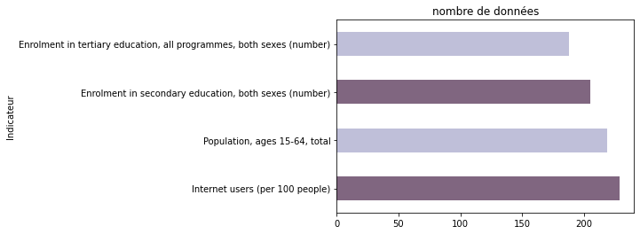

```python
my_colors = [(0.5,0.4,0.5), (0.75, 0.75, 0.85)]
df.plot.barh(x='Indicator Name', y='Study_years', title="nombre de données", xlabel='Indicateur', color=my_colors, legend=False)
plt.show()
```

Les 4 indicateurs choisis ont environ 200 données chacun.

#### Création de deux Dataset finaux filtrés en fonction de nos indicateurs choisis.

###### Récupération des lignes traitant uniquement nos indicateurs et en fonction des régions

```python
data_areas = Data_Study[Data_Study['Country Name'].isin(areas)][Data_Study['Indicator Code'].isin(indicateurs)]
#data_areas.head()
data_areas["Indicator Name"] = data_areas["Indicator Name"].apply(lambda x: x.replace("Enrolment in secondary education, both sexes (number)", "Secondary education"))
data_areas["Indicator Name"] = data_areas["Indicator Name"].apply(lambda x: x.replace("Enrolment in tertiary education, all programmes, both sexes (number)","Tertiary education"))
data_areas["Indicator Name"] = data_areas["Indicator Name"].apply(lambda x: x.replace("Internet users (per 100 people)", "Internet users"))
data_areas["Indicator Name"] = data_areas["Indicator Name"].apply(lambda x: x.replace("Population, ages 15-64, total", "Population (15-64)"))
data_areas.head()
```

|  | Country Name | Country Code | Indicator Name | Indicator Code | Region | Study_years |
| --- | --- | --- | --- | --- | --- | --- |
| 1191 | Arab World | ARB | Secondary education | SE.SEC.ENRL | NaN | 2.626794e+07 |
| 1204 | Arab World | ARB | Tertiary education | SE.TER.ENRL | NaN | 6.795613e+06 |
| 1375 | Arab World | ARB | Internet users | IT.NET.USER.P2 | NaN | 1.367292e+01 |
| 2486 | Arab World | ARB | Population (15-64) | SP.POP.1564.TO | NaN | 1.868050e+08 |
| 4856 | East Asia & Pacific | EAS | Secondary education | SE.SEC.ENRL | NaN | 1.475797e+08 |

###### Récupération des lignes traitant uniquement nos indicateurs et en fonction des pays choisis

```python
data_countries = Data_Study[Data_Study['Country Name'].isin(countries)][Data_Study['Indicator Code'].isin(indicateurs)]
data_countries["Indicator Name"] = data_countries["Indicator Name"].apply(lambda x: x.replace("Enrolment in secondary education, both sexes (number)", "Secondary education"))
data_countries["Indicator Name"] = data_countries["Indicator Name"].apply(lambda x: x.replace("Enrolment in tertiary education, all programmes, both sexes (number)","Tertiary education"))
data_countries["Indicator Name"] = data_countries["Indicator Name"].apply(lambda x: x.replace("Internet users (per 100 people)", "Internet users"))
data_countries["Indicator Name"] = data_countries["Indicator Name"].apply(lambda x: x.replace("Population, ages 15-64, total", "Population (15-64)"))
data_countries.head()
```

|  | Country Name | Country Code | Indicator Name | Indicator Code | Region | Study_years |
| --- | --- | --- | --- | --- | --- | --- |
| 96481 | Albania | ALB | Secondary education | SE.SEC.ENRL | Europe & Central Asia | 3.596865e+05 |
| 96494 | Albania | ALB | Tertiary education | SE.TER.ENRL | Europe & Central Asia | 8.041400e+04 |
| 96665 | Albania | ALB | Internet users | IT.NET.USER.P2 | Europe & Central Asia | 2.254072e+01 |
| 97776 | Albania | ALB | Population (15-64) | SP.POP.1564.TO | Europe & Central Asia | 1.941948e+06 |
| 100146 | Algeria | DZA | Secondary education | SE.SEC.ENRL | Middle East & North Africa | 3.800576e+06 |

## Analyse

### **Analyse de nos indicateurs.**

#### Analyse statistique sans distinstion de pays ou de région.

```python
Data_Study[Data_Study["Indicator Code"].isin(indicateurs)][["Indicator Name", "Indicator Code", "Study_years"]].groupby(['Indicator Name', 'Indicator Code']).describe()
```

| Indicator Name | Indicator Code | Study_years count | Study_years mean | Study_years std | Study_years min | Study_years 25% | Study_years 50% | Study_years 75% | Study_years max |
| --- | --- | --- | --- | --- | --- | --- | --- | --- | --- |
| Enrolment in secondary education, both sexes (number) | SE.SEC.ENRL | 205.0 | 1.602213e+07 | 5.782920e+07 | 1114.0 | 1.056080e+05 | 5.915490e+05 | 3.800576e+06 | 4.916559e+08 |
| Enrolment in tertiary education, all programmes, both sexes (number) | SE.TER.ENRL | 188.0 | 4.770593e+06 | 1.583654e+07 | 5.0 | 2.362825e+04 | 1.955342e+05 | 1.310947e+06 | 1.381289e+08 |
| Internet users (per 100 people) | IT.NET.USER.P2 | 229.0 | 2.057119e+01 | 1.853226e+01 | 0.0 | 4.220329e+00 | 1.614744e+01 | 3.307811e+01 | 8.000000e+01 |
| Population, ages 15-64, total | SP.POP.1564.TO | 219.0 | 1.275306e+08 | 4.760221e+08 | 54314.0 | 1.678121e+06 | 5.298222e+06 | 2.558678e+07 | 4.160843e+09 |

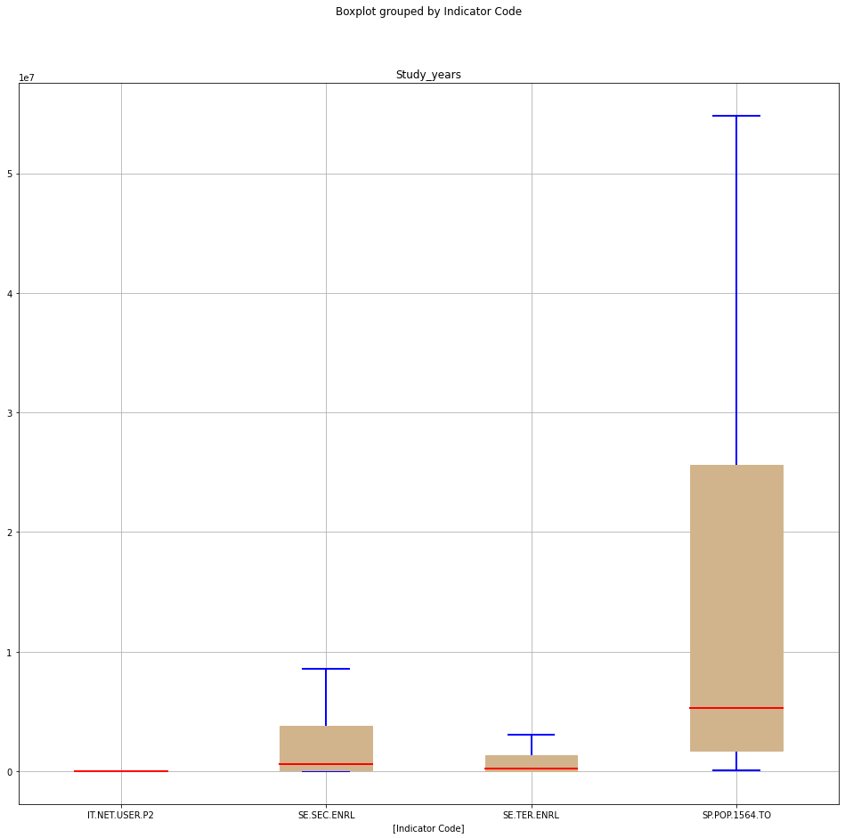

```python
graphe = Data_Study[Data_Study['Indicator Code'].isin(indicateurs)][['Indicator Code', 'Study_years']]
graphe.boxplot(by='Indicator Code', showfliers=False, figsize=(16,15), showcaps=True, patch_artist=True, color='tan',medianprops={'linestyle': '-', 'linewidth': 2, 'color': 'red',}, whiskerprops={'linestyle': '-', 'linewidth': 2, 'color' : 'blue'}, capprops={'linestyle': '-', 'linewidth': 2, 'color':'blue'})
```

On remarque que l'indicateur qui représente la population entre 15 et 64 ans, a une distribution beaucoup plus dispersée que les autres indicateurs. Hypothèse : Les personnes inscrites dans le secondaire et le tertiaire ne représentent qu'une infime partie des personnes qui ont entre 15 et 64 ans. L'indicateur sur l'utilisation d'internet étant représenté en pourcentage (données sur une base de 100 personnes), il n'est pas possible de le comparer aux trois autres indicateurs.

```python
SEC = ["SE.SEC.ENRL"]
TER = ["SE.TER.ENRL"]
NET = ["IT.NET.USER.P2"]
POP = ["SP.POP.1564.TO"]
```

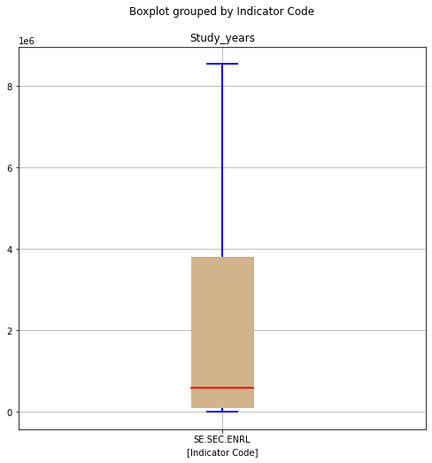

```python
graphe = Data_Study[Data_Study['Indicator Code'].isin(SEC)][['Indicator Code', 'Study_years']]
graphe.boxplot(by='Indicator Code', showfliers=False, figsize=(8, 8), showcaps=True, patch_artist=True, color='tan',medianprops={'linestyle': '-', 'linewidth': 2, 'color': 'red',}, whiskerprops={'linestyle': '-', 'linewidth': 2, 'color' : 'blue'}, capprops={'linestyle': '-', 'linewidth': 2, 'color':'blue'})
```

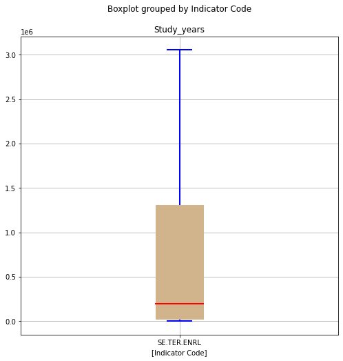

```python
graphe = Data_Study[Data_Study['Indicator Code'].isin(TER)][['Indicator Code', 'Study_years']]
graphe.boxplot(by='Indicator Code', showfliers=False, figsize=(8, 8), showcaps=True, patch_artist=True, color='tan',medianprops={'linestyle': '-', 'linewidth': 2, 'color': 'red',}, whiskerprops={'linestyle': '-', 'linewidth': 2, 'color' : 'blue'}, capprops={'linestyle': '-', 'linewidth': 2, 'color':'blue'})
```

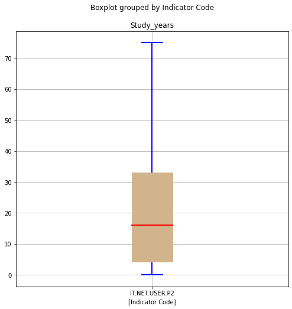

```python
graphe = Data_Study[Data_Study['Indicator Code'].isin(NET)][['Indicator Code', 'Study_years']]
graphe.boxplot(by='Indicator Code', showfliers=False, figsize=(8, 8), showcaps=True, patch_artist=True, color='tan',medianprops={'linestyle': '-', 'linewidth': 2, 'color': 'red',}, whiskerprops={'linestyle': '-', 'linewidth': 2, 'color' : 'blue'}, capprops={'linestyle': '-', 'linewidth': 2, 'color':'blue'})
```

- Environ 25% des pays étudiés ont moins de 4% de leur population qui utilisent internet (il s'agit de pays pauvres) et environ 75% des pays étudiés ont beaucoup plus de personnes qui ont accès à internet (25% des pays ont plus de 33% de leur population qui utilise internet).
- Environ 50% des pays étudiés ont moins de 16% de leur population qui a accès à internet.

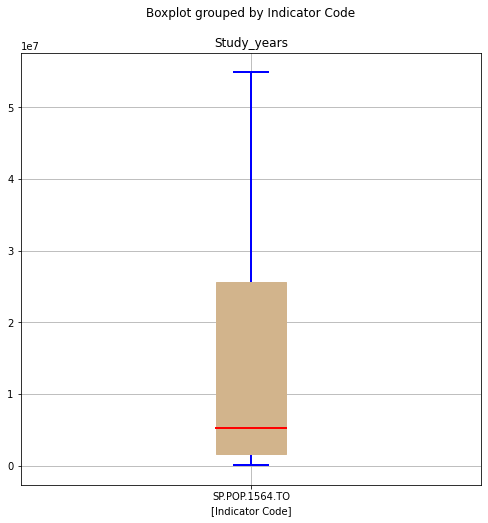

```python
graphe = Data_Study[Data_Study['Indicator Code'].isin(POP)][['Indicator Code', 'Study_years']]
graphe.boxplot(by='Indicator Code', showfliers=False, figsize=(8, 8), showcaps=True, patch_artist=True, color='tan',medianprops={'linestyle': '-', 'linewidth': 2, 'color': 'red',}, whiskerprops={'linestyle': '-', 'linewidth': 2, 'color' : 'blue'}, capprops={'linestyle': '-', 'linewidth': 2, 'color':'blue'})
```

- Environ 25% des pays étudiés ont moins de 1 678 121 personnes qui ont entre 15 et 64 ans (il s'agit de petits pays). Environ 75% des pays étudiés ont plus de 1 678 121 personnes qui ont entre 15 et 64 ans (25% ont plus de 25 586 780 personnes ont entre 15 et 64 ans).
- Environ 50% des pays étudiés ont moins de 5 298 222 personnes qui ont entre 15 et 64 ans.

#### Analyse statistique de nos indicateurs par zone géographique.

```python
def description_indicateurs(df, indicateurs, groupe):
    df_per_indicator = pd.DataFrame()
    for indicateur in indicateurs:
        df_temp = df[df['Indicator Code'] == indicateur]
        df_temp[indicateur] = df['Study_years']
        df_temp.drop(['Study_years', 'Indicator Name', 'Indicator Code'], inplace=True, axis=1)

        if df_per_indicator.empty is False:
            df_per_indicator = df_per_indicator.merge(right = df_temp, how = 'outer', on = ['Country Code', 'Country Name', 'Region']).sort_values(by='Country Name')
        else:
            df_per_indicator = df_temp


    description = df_per_indicator.groupby([groupe])[indicateurs].describe(percentiles = [0.5])
    for indicateur in indicateurs:
        description[(indicateur, 'sum')] = description[(indicateur, 'count')] * description[(indicateur, 'mean')]
    colonnes = []
    for indicateur in indicateurs:
        for stat in ['mean', 'std', '50%', 'sum'] :
            colonnes += [(indicateur, stat)]
    description = description[colonnes]
    description.reset_index(inplace=True)
    return description, df_per_indicator
```

```python
description_countries, df_countries = description_indicateurs(data_countries, indicateurs, 'Region')
description_zones, df_zones     = description_indicateurs(data_areas, indicateurs, 'Country Name')
```

```python
description_zones
```

|  | Country Name | SE.SEC.ENRL mean | SE.SEC.ENRL std | SE.SEC.ENRL 50% | SE.SEC.ENRL sum | SE.TER.ENRL mean | SE.TER.ENRL std | SE.TER.ENRL 50% | SE.TER.ENRL sum | SP.POP.1564.TO mean | SP.POP.1564.TO std | SP.POP.1564.TO 50% | SP.POP.1564.TO sum | IT.NET.USER.P2 mean | IT.NET.USER.P2 std | IT.NET.USER.P2 50% | IT.NET.USER.P2 sum |
| --- | --- | --- | --- | --- | --- | --- | --- | --- | --- | --- | --- | --- | --- | --- | --- | --- | --- |
| 0 | Arab World | 26267941.0 | NaN | 26267941.0 | 26267941.0 | 6.795613e+06 | NaN | 6.795613e+06 | 6.795613e+06 | 1.868050e+08 | NaN | 1.868050e+08 | 1.868050e+08 | 13.672917 | NaN | 13.672917 | 13.672917 |
| 1 | East Asia & Pacific | 147579732.0 | NaN | 147579732.0 | 147579732.0 | 3.945356e+07 | NaN | 3.945356e+07 | 3.945356e+07 | 1.458420e+09 | NaN | 1.458420e+09 | 1.458420e+09 | 18.818623 | NaN | 18.818623 | 18.818623 |
| 2 | Europe & Central Asia | 80480044.0 | NaN | 80480044.0 | 80480044.0 | 3.318544e+07 | NaN | 3.318544e+07 | 3.318544e+07 | 5.871547e+08 | NaN | 5.871547e+08 | 5.871547e+08 | 32.681569 | NaN | 32.681569 | 32.681569 |
| 3 | Latin America & Caribbean | 57958326.0 | NaN | 57958326.0 | 57958326.0 | 1.632724e+07 | NaN | 1.632724e+07 | 1.632724e+07 | 3.557445e+08 | NaN | 3.557445e+08 | 3.557445e+08 | 18.381056 | NaN | 18.381056 | 18.381056 |
| 4 | Middle East & North Africa | 33923334.0 | NaN | 33923334.0 | 33923334.0 | 9.274999e+06 | NaN | 9.274999e+06 | 9.274999e+06 | 2.172816e+08 | NaN | 2.172816e+08 | 2.172816e+08 | 12.885774 | NaN | 12.885774 | 12.885774 |
| 5 | North America | 25884831.0 | NaN | 25884831.0 | 25884831.0 | 1.839120e+07 | NaN | 1.839120e+07 | 1.839120e+07 | 2.173912e+08 | NaN | 2.173912e+08 | 2.173912e+08 | 54.211482 | NaN | 54.211482 | 54.211482 |
| 6 | South Asia | 111357252.0 | NaN | 111357252.0 | 111357252.0 | 1.710642e+07 | NaN | 1.710642e+07 | 1.710642e+07 | 9.199538e+08 | NaN | 9.199538e+08 | 9.199538e+08 | 3.716431 | NaN | 3.716431 | 3.716431 |
| 7 | Sub-Saharan Africa | 35142246.0 | NaN | 35142246.0 | 35142246.0 | 4.452334e+06 | NaN | 4.452334e+06 | 4.452334e+06 | 4.048978e+08 | NaN | 4.048978e+08 | 4.048978e+08 | 3.757337 | NaN | 3.757337 | 3.757337 |

#### Quelles sont les régions du monde à privilégier pour notre expension à l'international ?

```python
df_pv=pd.pivot_table(data_areas, index=['Indicator Name', 'Country Name'], values='Study_years', aggfunc='sum')
df_pv.head()
```

| Indicator Name | Country Name | Study_years |
| --- | --- | --- |
| Internet users | Arab World | 13.672917 |
|  | East Asia & Pacific | 18.818623 |
|  | Europe & Central Asia | 32.681569 |
|  | Latin America & Caribbean | 18.381056 |
|  | Middle East & North Africa | 12.885774 |

```python
df_pv_areas = pd.pivot_table(data_areas, index = 'Indicator Name', columns = 'Country Name', values = 'Study_years', aggfunc = 'sum')
```

[output not shown]

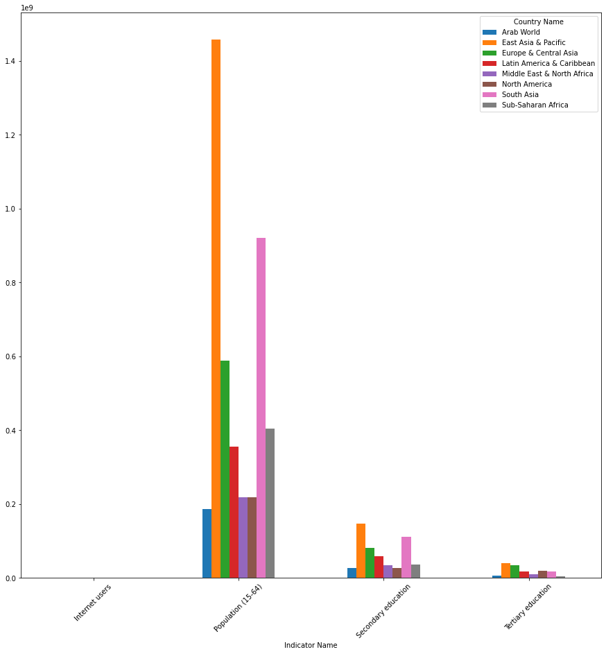

```python
df_pv_areas.plot( kind='bar', figsize=(15,15))
plt.xticks(rotation=45)
```

On peut voir que certaines régions du monde comme East Asia & Pacific, South Asia et Europe et central Asia sont les régions qui ressortent de cette étude. Cependant il est diffcile d'analyser correctement le graphique, c'est pourquoi chaque indicateur va être analysé séparement.

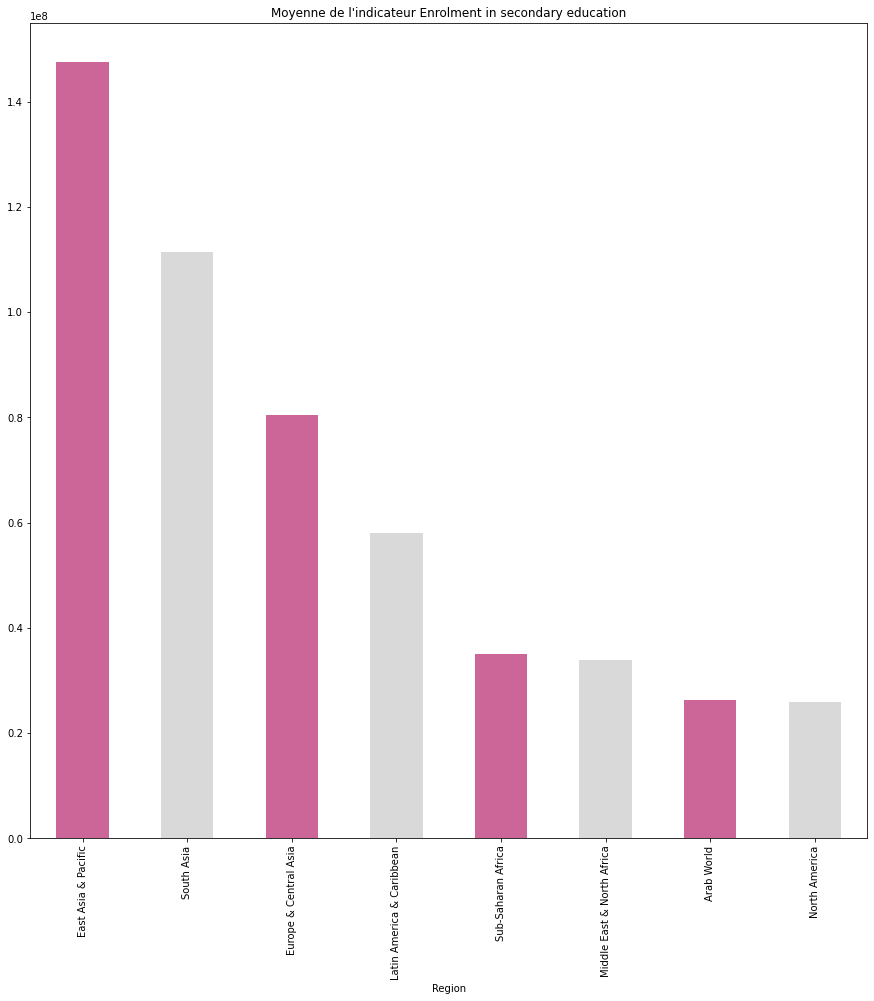

```python
indicator_1a = df_pv_areas.loc["Secondary education"].sort_values(ascending=False).head(15)
my_colors = [(0.8,0.4,0.6), (0.85, 0.85, 0.85)]
ax = indicator_1a.plot(kind="bar", figsize=(15,15), title="Moyenne de l'indicateur Enrolment in secondary education", xlabel='Region', color=my_colors)
plt.show()
```

En observant le nombre moyen de personnes inscrites dans le secondaire dans chaque région du monde, on remarque que la majorité des lycéens se trouve dans les régions suivantes : East Asia & Pacific, South Asia, Europe & central Asia et Latin America & Caribbean.

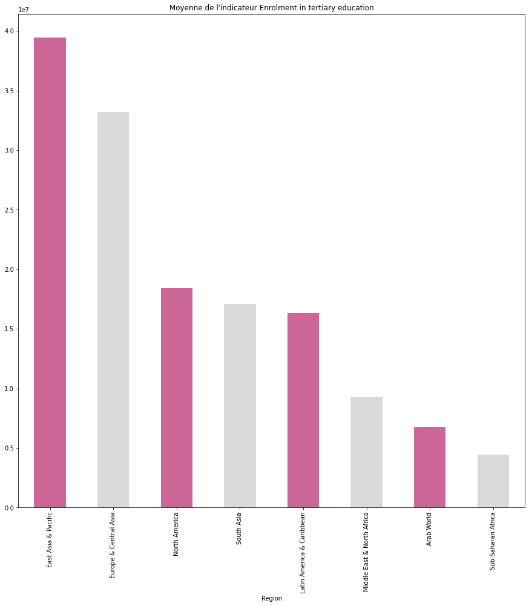

```python
indicator_2a = df_pv_areas.loc["Tertiary education"].sort_values(ascending=False).head(15)
my_colors = [(0.8,0.4,0.6), (0.85, 0.85, 0.85)]
ax = indicator_2a.plot(kind="bar", figsize=(15,15), title="Moyenne de l'indicateur Enrolment in tertiary education", xlabel='Region', color=my_colors)
plt.show()
```

En observant le nombre moyen de personnes inscrites dans le tertiaire dans chaque région du monde, on remarque que la majorité des étudiants se trouve dans les régions suivantes : East Asia & Pacific, Europe & central Asia, North America et South Asia.

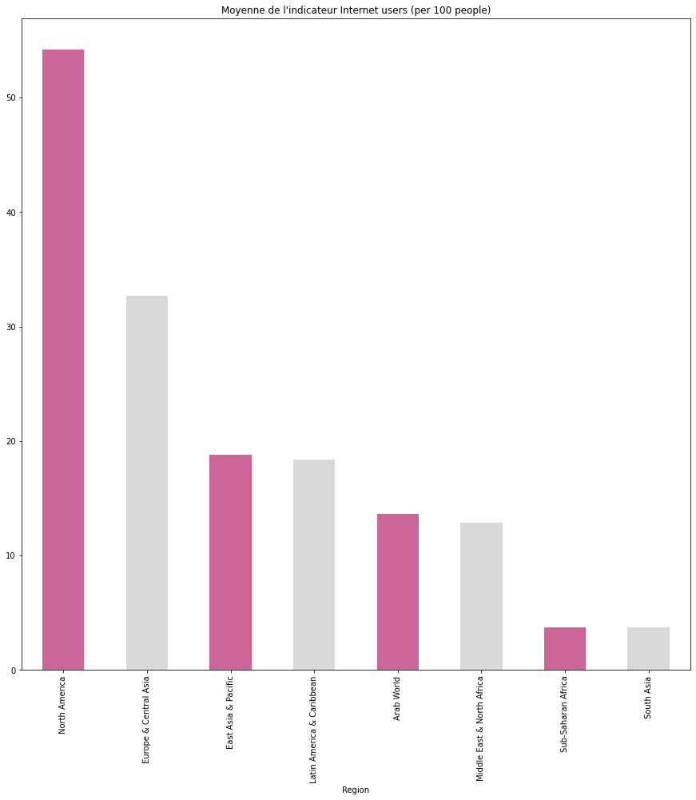

```python
indicator_3a = df_pv_areas.loc["Internet users"].sort_values(ascending=False).head(15)
my_colors = [(0.8,0.4,0.6), (0.85, 0.85, 0.85)]
ax = indicator_3a.plot(kind="bar", figsize=(15,15), title="Moyenne de l'indicateur Internet users (per 100 people)", xlabel='Region', color=my_colors)
fig = ax.get_figure()
plt.show()
```

En observant le taux moyen d'accès à internet par région, il est plus aisé d'utiliser internet dans les régions suivantes : North America, Europe & Central Asia, East Asia & Pacific et Latin America & Caribbean.

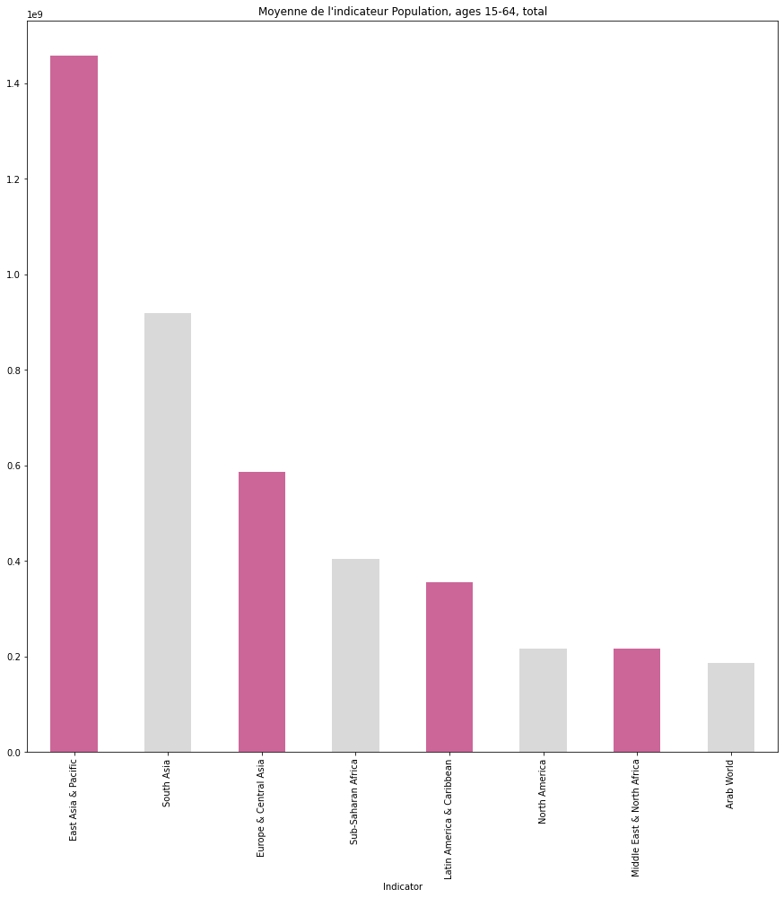

```python
indicator_4a = df_pv_areas.loc["Population (15-64)"].sort_values(ascending=False).head(15)
my_colors = [(0.8,0.4,0.6), (0.85, 0.85, 0.85)]
ax = indicator_4a.plot(kind="bar", figsize=(15,15), title="Moyenne de l'indicateur Population, ages 15-64, total", xlabel='Region', color=my_colors)
fig = ax.get_figure()
ax.set_xlabel("Indicator")
plt.show()
```

En observant le nombre moyen de personnes agées entre 15 et 64 ans, on remarque que la majorité des personnes susceptibles de s'intéresser à nos services se situe dans les régions suivantes : East Asia & Pacific, South Asia, Europe & central Asia.

#### Quels sont les pays à privilégier pour notre expension à l'internationnal ?

###### Taux de remplissage des données selon les indicateurs et les pays choisis

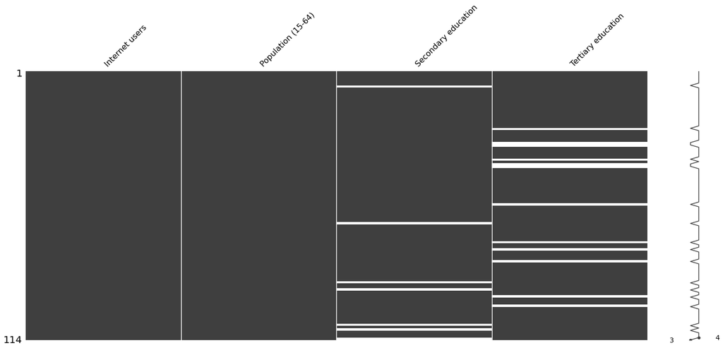

```python
df_pv_c = pd.pivot_table(data_countries, index=['Country Name', 'Indicator Name'], values='Study_years', dropna=False)
df_pv_countries = pd.pivot_table(df_pv_c, index = 'Indicator Name', columns = 'Country Name', values = 'Study_years', aggfunc = 'min', dropna=False)
df_pv_countries_T=df_pv_countries.T
msno.matrix(df_pv_countries_T)
```

Les pays et les indicateurs choisis sont des choix judicieux car il y a peu de données manquantes, généralement il ne manque des données que sur un des quatres indicateurs. L'indicateur, essentiel dans notre étude sur le développement de cours e-learning, qui quantifie l'accès à internet est traité par la totalité des pays.

###### Quels sont les pays satisfaisant nos critères ?

[output not shown]

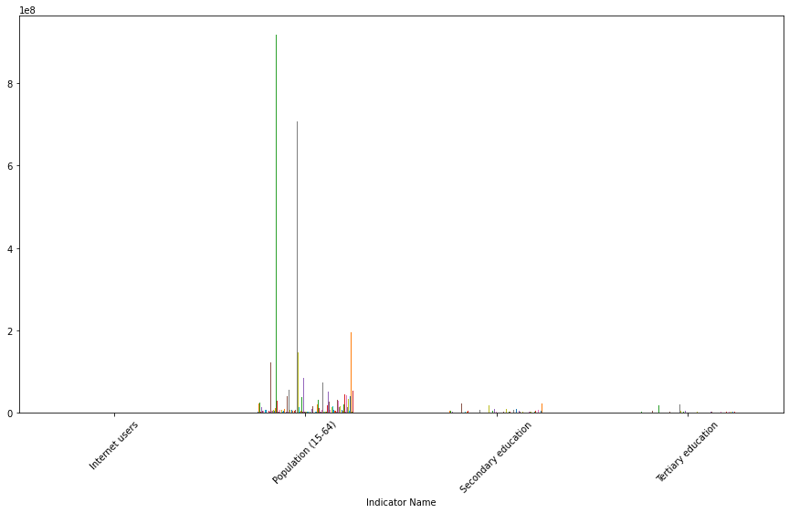

```python
df_pv_countries.plot( kind='bar', figsize=(15,8), legend=None)
plt.xticks(rotation=45)
```

On peut voir que certains pays ressortent de cette étude. Cependant il est diffcile d'analyser correctement le graphique, c'est pourquoi chaque indicateur va être analysé séparement.

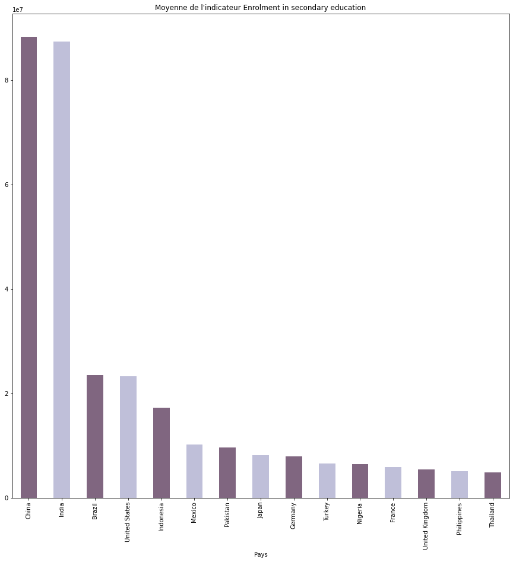

```python
indicator_1c = df_pv_countries.loc["Secondary education"].sort_values(ascending=False).head(15)
my_colors = [(0.5,0.4,0.5), (0.75, 0.75, 0.85)]
ax = indicator_1c.plot(kind="bar", figsize=(15,15), title="Moyenne de l'indicateur Enrolment in secondary education", xlabel='Pays', color=my_colors)
fig = ax.get_figure()
plt.show()
```

En observant le nombre moyen de personnes inscrites dans le secondaire dans chaque pays du monde, on remarque que la majorité des lycéens se trouve dans les pays suivants : Chine, Inde , Brésil, Etat-Unis, Indonésie.

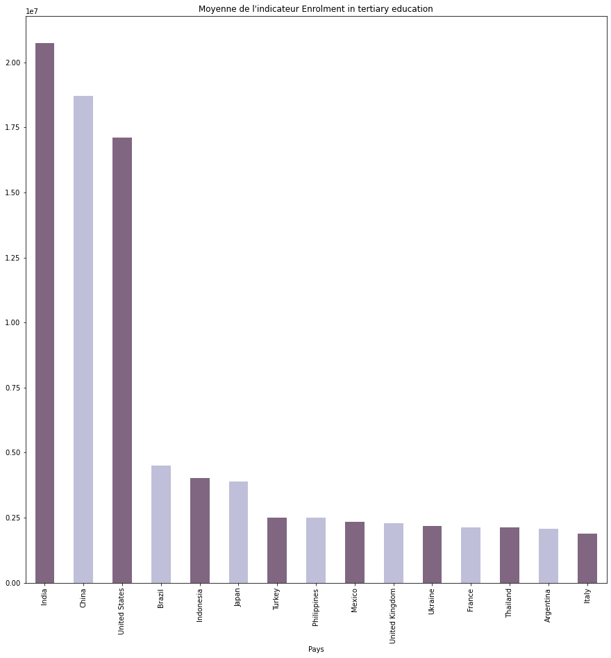

```python
indicator_2c = df_pv_countries.loc["Tertiary education"].sort_values(ascending=False).head(15)
my_colors = [(0.5,0.4,0.5), (0.75, 0.75, 0.85)]
ax = indicator_2c.plot(kind="bar", figsize=(15,15), title="Moyenne de l'indicateur Enrolment in tertiary education", xlabel='Pays', color=my_colors)
fig = ax.get_figure()
plt.show()
```

En observant le nombre moyen de personnes inscrites dans le tertiaire dans chaque pays du monde, on remarque que la majorité des étudiants se trouve dans les pays suivants : Inde, Chine, Etat-Unis, Brésil, Indonésie.

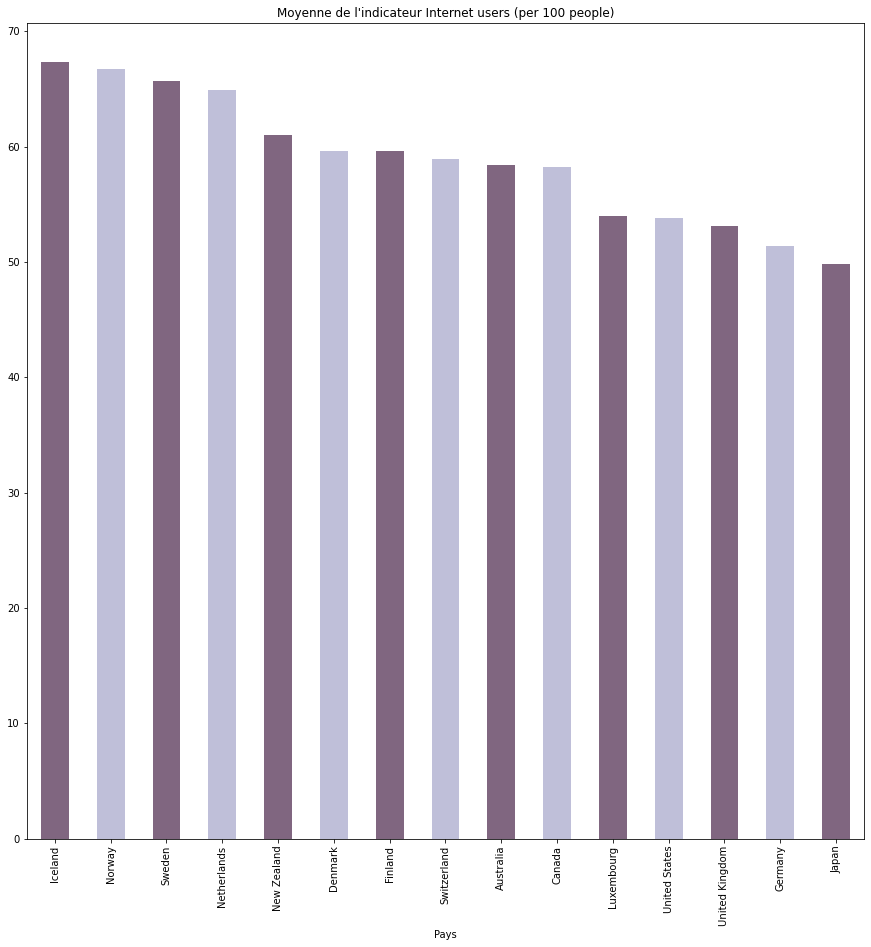

```python
indicator_3c = df_pv_countries.loc["Internet users"].sort_values(ascending=False).head(15)
my_colors = [(0.5,0.4,0.5), (0.75, 0.75, 0.85)]
ax = indicator_3c.plot(kind="bar", figsize=(15,15), title="Moyenne de l'indicateur Internet users (per 100 people)", xlabel='Pays', color=my_colors)
fig = ax.get_figure()
plt.show()
```

En observant le taux moyen d'accès à internet par pays, il est possible de dire que tous les pays riches, développés ont un accès facile à internet.

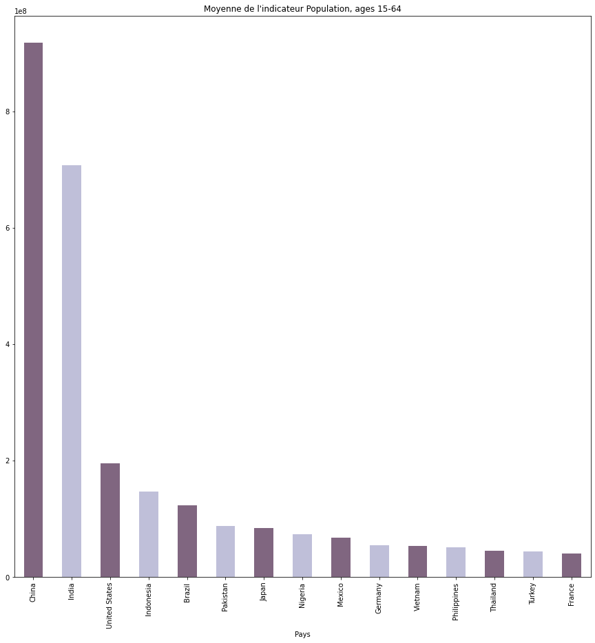

```python
indicator_4c = df_pv_countries.loc["Population (15-64)"].sort_values(ascending=False).head(15)
my_colors = [(0.5,0.4,0.5), (0.75, 0.75, 0.85)]
ax = indicator_4c.plot(kind="bar", figsize=(15,15), title="Moyenne de l'indicateur Population, ages 15-64", xlabel='Pays', color=my_colors)
fig = ax.get_figure()
plt.show()
```

En observant le nombre moyen de personnes agées entre 15 et 64 ans, on remarque que la majorité des personnes susceptibles de s'intéresser à nos services se trouve dans les pays suivants : Chine, Inde, Etat-Unis, Indonésie, Brésil, .

#### Première conclusion : Où est-il intéressant de s'implanter ?

Après cette première analyse, il serait intéressant de s'implanter **en Asie de l'Est et Pacific, en Asie du Sud, en Europe et Asie centrale, en Amérique du Nord et en Latin America & Caribbean**. Et plus précisément **en Chine, en Inde, aux Etats-Unis, au Brésil et en Indonésie**.

### **Analyses complémentaires pour conforter notre première conclusion**

#### Evolution de nos indicateurs en fonction des 5 pays qui ressortent de la première étude.

```python
win_countries = ['China', 'India', 'United States', 'Indonesia', 'Brazil']
ch = ['China']
ind = ['India']
USA = ['United States']
indo = ['Indonesia']
braz = ['Brazil']
data_winners = Stats_Data[Stats_Data['Country Name'].isin(win_countries)][Stats_Data['Indicator Code'].isin(indicateurs)]
```

Formation d'un nouveau Dataset contenant uniquement les lignes concernant nos pays et nos indicateurs.

###### La Chine.

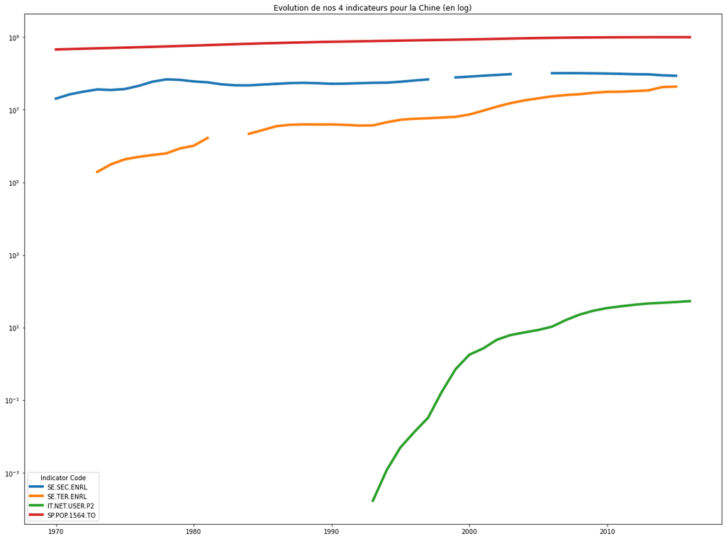

```python
CHINA = data_winners[data_winners['Country Name'].isin(ch)]
CHINA = CHINA.drop(columns=['Country Name', 'Country Code', 'Indicator Name'])
CHINA = CHINA.set_index("Indicator Code")
CHINA = CHINA.T
CHINA.plot(linewidth=4,kind='line',figsize=(20,15), title='Evolution de nos 4 indicateurs pour la Chine (en log)').set_yscale('log')
```

###### L'Inde.

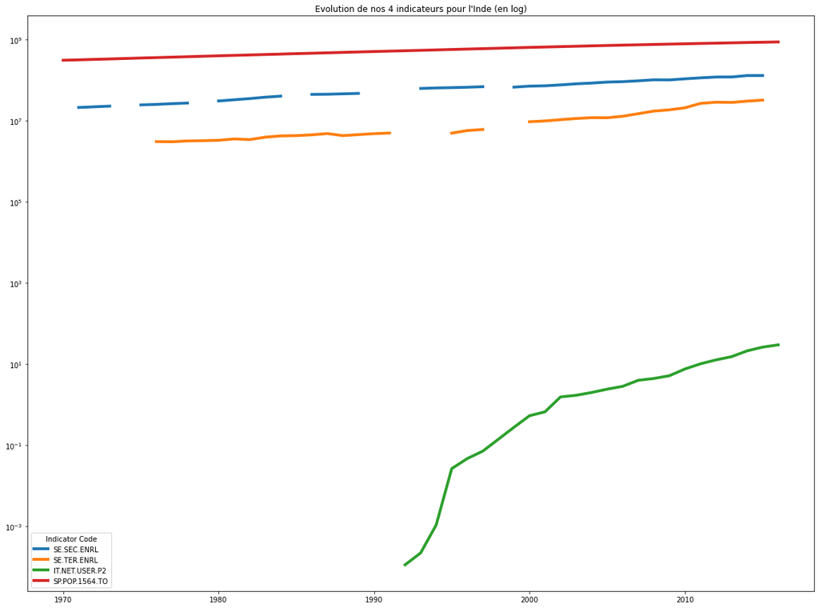

```python
INDIA = data_winners[data_winners['Country Name'].isin(ind)]
INDIA = INDIA.drop(columns=['Country Name', 'Country Code', 'Indicator Name'])
INDIA = INDIA.set_index("Indicator Code")
INDIA = INDIA.T
INDIA.plot(linewidth=4, kind='line',figsize=(20,15), title='Evolution de nos 4 indicateurs pour l\'Inde (en log)').set_yscale('log')
```

La population est depuis le début des prises des données jeune mais il y a au fil des années une augmentation de ce nombre. Le nombre de personne dans le secondaire est en augmentation ainsi que le nombre de personnes inscrites dans le tertiaire qui est en forte évolution. Cependant, une partie des personnes inscrites dans le secondaire ne continuent pas leurs études dans le tertiaire. Enfin, suite à l'apparition d'internet, la population a commencé à s'équiper mais l'acquisition d'internet s'effectue au fil des années et continue toujours aujourd'hui car cet indicateur est encore en augmentation.

###### Les Etats Unis.

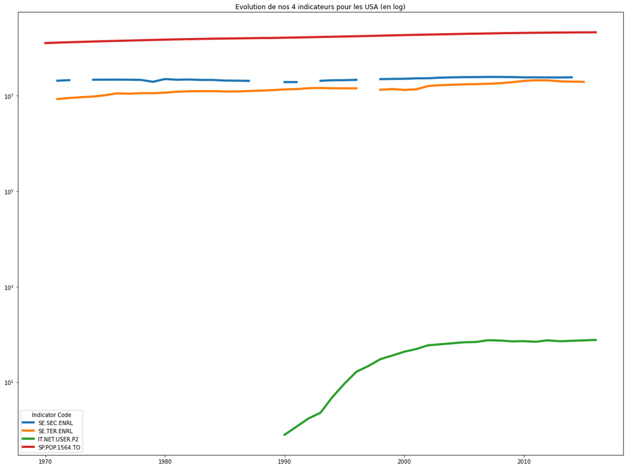

```python
USA = data_winners[data_winners['Country Name'].isin(USA)]
USA = USA.drop(columns=['Country Name', 'Country Code', 'Indicator Name'])
USA = USA.set_index("Indicator Code")
USA = USA.T
USA.plot(linewidth=4,kind='line',figsize=(20,15), title='Evolution de nos 4 indicateurs pour les USA (en log)').set_yscale('log')
```

###### L'Indonésie.

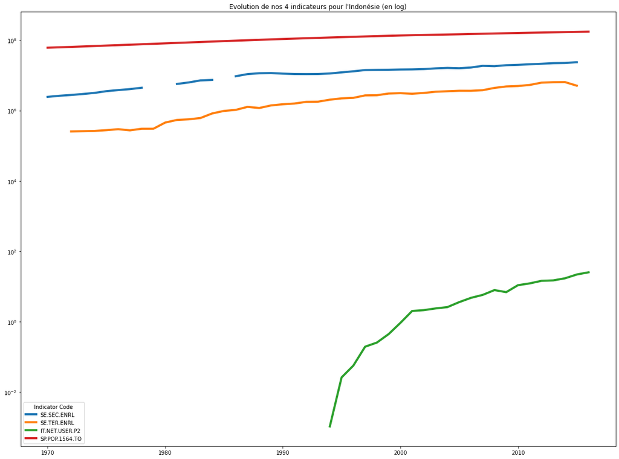

```python
INDO = data_winners[data_winners['Country Name'].isin(indo)]
INDO = INDO.drop(columns=['Country Name', 'Country Code', 'Indicator Name'])
INDO = INDO.set_index("Indicator Code")
INDO = INDO.T
INDO.plot(linewidth=4,kind='line',figsize=(20,15), title='Evolution de nos 4 indicateurs pour l\'Indonésie (en log)').set_yscale('log')
```

La population est depuis le début des prises des données jeune mais il y a au fil des années une petite augmentation de ce nombre. Le nombre de personne dans le secondaire est en augmentation ainsi que le nombre de personnes inscrites dans le tertiaire. Cependant, une partie les personnes inscrite dans le secondaire ne continuent pas leurs études dans le tertiaire. Enfin, suite à l'apparition d'internet, la population a commencée à s'équiper mais l'acquisition d'internet s'effectue au fil des années et continue toujours aujourd'hui car cet indicateur est encore en augmentation dûe à une forte population.

###### Le Brésil.

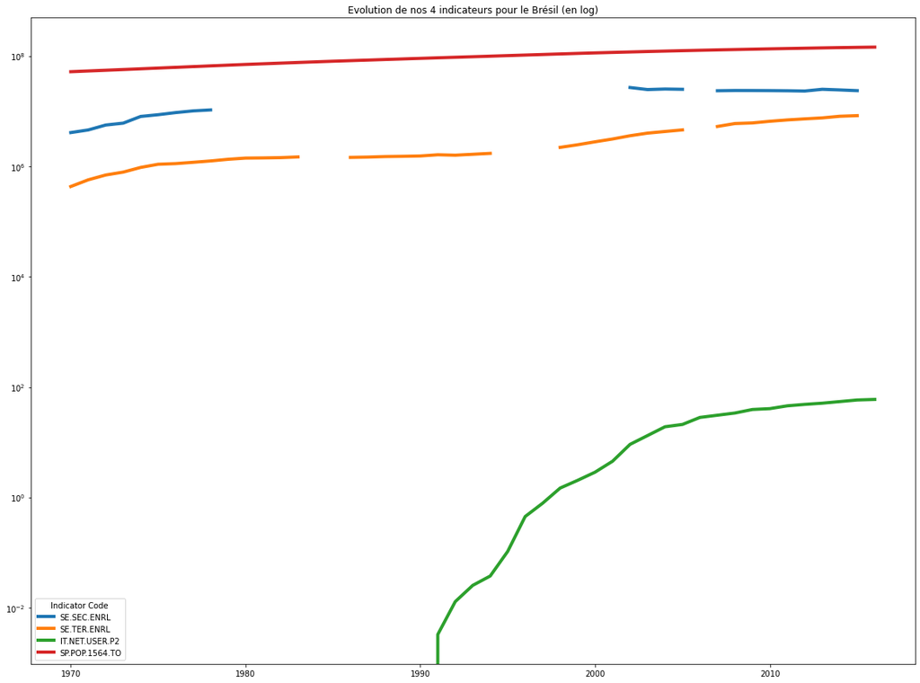

```python
BRAZ = data_winners[data_winners['Country Name'].isin(braz)]
BRAZ = BRAZ.drop(columns=['Country Name', 'Country Code', 'Indicator Name'])
BRAZ = BRAZ.set_index("Indicator Code")
BRAZ = BRAZ.T
BRAZ.plot(linewidth=4,kind='line',figsize=(20,15), title='Evolution de nos 4 indicateurs pour le Brésil (en log)').set_yscale('log')
```